# Bike Share Case Study

## Intro

The business task for this case study is to find out how annual members and casual riders use divvy bikeshare service in Chicago differently over the past year. Member riders are defined as having a subscription to the bike share service which allows them 45mins of ride time per trip before any extra charge, while casual riders pay per ride and based on time used. Day pass user are included in casual users and a day pass includes 3hrs of ride time for free per trip.

First I’ll load up the packages that I’ll need for this task.

```r
install.packages('tidyverse')
install.packages('ggplot2')
```

```r
library(tidyverse)
library(ggplot2)
library(readr)
library(lubridate)
```

Now I’ll load all the data from the past year found [here.](https://divvy-tripdata.s3.amazonaws.com/index.html) The data has already been pre-processed by the provider as stated on their [website](https://divvybikes.com/system-data) which includes removal of trips for staff use and any trips that were under 60 seconds in duration to remove any false starts. It includes the following:

- Trip start day and time
- Trip end day and time
- Trip start station
- Trip end station
- Rider type

## Loading Up and cleaning data

```r
setwd("C:/Users/Chris/Desktop/Case study data/UNZIPPED Case study data")
X202404_tripdata <- read_csv('202404-divvy-tripdata.csv')
X202403_tripdata <- read_csv('202403-divvy-tripdata.csv')
X202402_tripdata <- read_csv('202402-divvy-tripdata.csv')
X202401_tripdata <- read_csv('202401-divvy-tripdata.csv')
X202312_tripdata <- read_csv('202312-divvy-tripdata.csv')
X202311_tripdata <- read_csv('202311-divvy-tripdata.csv')
X202310_tripdata <- read_csv('202310-divvy-tripdata.csv')
X202309_tripdata <- read_csv('202309-divvy-tripdata.csv')
X202308_tripdata <- read_csv('202308-divvy-tripdata.csv')
X202307_tripdata <- read_csv('202307-divvy-tripdata.csv')
X202306_tripdata <- read_csv('202306-divvy-tripdata.csv')
X202305_tripdata <- read_csv('202305-divvy-tripdata.csv')
```

Then I’ll take all the monthly data and combine it into 1 larger data frame for ease of use.

```r
tripdata_202404_202304 <- list(X202305_tripdata, X202306_tripdata, X202307_tripdata, X202308_tripdata, X202309_tripdata, X202310_tripdata, X202311_tripdata, X202312_tripdata, X202401_tripdata, X202402_tripdata, X202403_tripdata, X202404_tripdata)

tripdata_joined <-tripdata_202404_202304 %>% reduce(full_join)
```

I’ll do a quick check to see that it all went together well and inspect some of the data

```r
str(tripdata_joined)
```

[output not shown]

Here I’ve noticed some of the trips contain null values for the end station names and id’s so I’ll clean those out for the time being

```r
tripdata_clean <- tripdata_joined %>% drop_na()
```

I’m going to quickly compare the number of trips done by members and casuals to see if removed records effected one group more than the other.

```r
joinedtemp <- tripdata_joined %>%
group_by(member_casual) %>%
summarise(ride_id = n())%>%
mutate(percent_of_riders = (ride_id/(sum(joinedtemp$ride_id)))*100)

cleanedtemp <- tripdata_clean %>%
group_by(member_casual) %>%
summarise(ride_id = n())%>%
mutate(percent_of_riders = (ride_id/(sum(cleanedtemp$ride_id)))*100)

head(joinedtemp)
```

| member_casual | ride_id | percent_of_riders |
| --- | --- | --- |
| casual | 2052652 | 35.76914 |
| member | 3685960 | 64.23086 |

```r
head(cleanedtemp)
```

| member_casual | ride_id | percent_of_riders |
| --- | --- | --- |
| casual | 1524678 | 35.16454 |
| member | 2811161 | 64.83546 |

```r
NA
```

Comparing these 2 tables shows that the difference caused by cleaning the empty records is less than 1%, for this project I would consider that acceptable.

Now that the data has been cleaned to extent I’ll move on to creating a new column to show the total trip length of each trip, this way we can see how the length of trips differs between the user groups

[figure not shown]

```r
tripdata_cleanV0 <- tripdata_clean %>%
  mutate(ride_length = (tripdata_clean$ended_at)-(tripdata_clean$started_at))

ggplot(data = tripdata_cleanV1, mapping = aes(y = ride_length, x = started_at))+
       geom_point(aes(colour=member_casual))
```

There are a few outliers that are making it hard to see the y-axis. Reading the Divvy website I’ve found that after 24 hours a user will be charged $250 for a stolen bike so I’ll also trim off any ride longer than 24 hours to be safe.

```r
tripdata_cleanV1 <- tripdata_cleanV0%>%
                      filter(ride_length >= 60)%>%
                      filter(ride_length <= 86400)
```

Now that the ride lengths have been cleaned up we can move on.

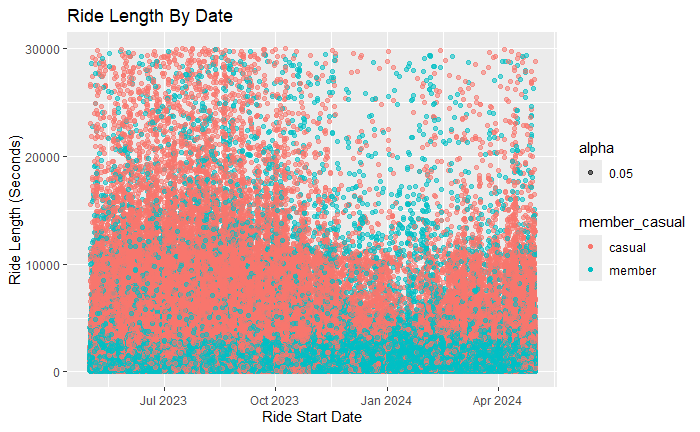

```r
ggplot(data = tripdata_cleanV1, mapping = aes(y = ride_length, x = started_at))+
      geom_point(aes (colour=member_casual, alpha = 0.05))+
      labs(title =  'Ride Length By Date ', x = 'Ride Start Date', y = 'Ride Length (Seconds)' )+
      ylim(60,30000)
```

While this plot is is a little crowded we can see a trend that shows causal users drop significantly over winter months while member users seem to keep doing trips. We can also see in this plot that casual users dominate the area from roughly 2500 seconds (41 minutes) on which shows that members are more often using the bikes for shorter trips . Lets look at some of this data this in more detail.

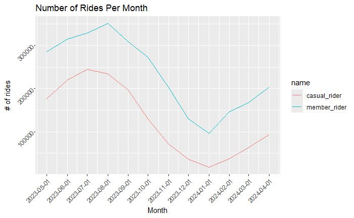

```r
member_vs_casual_month <- pivot_longer(
                              left_join(
                                tripdata_cleanV2 %>%
                                  filter(member_rider <- member_casual == 'member') %>%
                                  group_by(Month = lubridate::floor_date(started_at, unit = 'month')) %>%
                                  summarise(member_rider = n()),
                              tripdata_cleanV2 %>%
                                  filter(casual_rider <- member_casual == 'casual') %>%
                                  group_by(Month = lubridate::floor_date(started_at, unit = 'month')) %>%
                                  summarise(casual_rider = n())
                                        ),casual_rider:member_rider)
ggplot( data = (member_vs_casual_month), mapping = aes(Month))+
  geom_line(aes(y = value, color = name,))+
  scale_y_continuous(name = '# of rides',labels = function(x) format(x, scientific = FALSE))+
  scale_x_datetime(date_breaks = 'month')+
  theme(axis.text.x = element_text(angle = 45, hjust = 1 ),axis.text.y = element_text(angle = 45))+
  labs(title = 'Number of Rides Per Month')
```

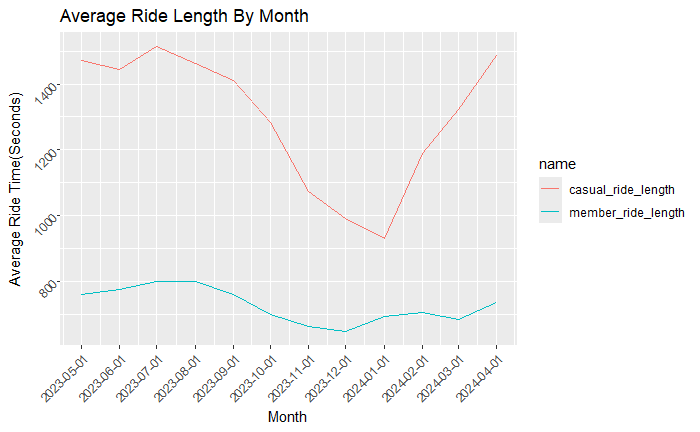

```r
ride_length_month <- pivot_longer(
                        left_join(
                          tripdata_cleanV2 %>%
                            filter(member_rider <- member_casual == 'member') %>%
                            group_by(Month = lubridate::floor_date(started_at, unit = 'month')) %>%
                            summarise(member_ride_length = mean(ride_length)),
                          tripdata_cleanV2 %>%
                            filter(casual_rider <- member_casual == 'casual') %>%
                            group_by(Month = lubridate::floor_date(started_at, unit = 'month')) %>%
                            summarise(casual_ride_length = mean(ride_length))
),casual_ride_length:member_ride_length)
ggplot( data = (ride_length_month), mapping = aes(Month))+
  geom_line(aes(y = value, color = name,))+
  scale_y_continuous(name = 'Average Ride Time(Seconds)',labels = function(x) format(x, scientific = FALSE))+
  scale_x_datetime(date_breaks = 'month')+
  theme(axis.text.x = element_text(angle = 45, hjust = 1 ),axis.text.y = element_text(angle = 45))+
  labs(title = 'Average Ride Length By Month')
```

With these 2 graphs we have gained new insights into the data. We can easily see how seasonal fluctuations effect the amount of rides, we also see that there are always more member rides than casual rides and that member rides on average have shorter rides with more consistent length. It may be worth looking at where these people are going to/from most commonly.

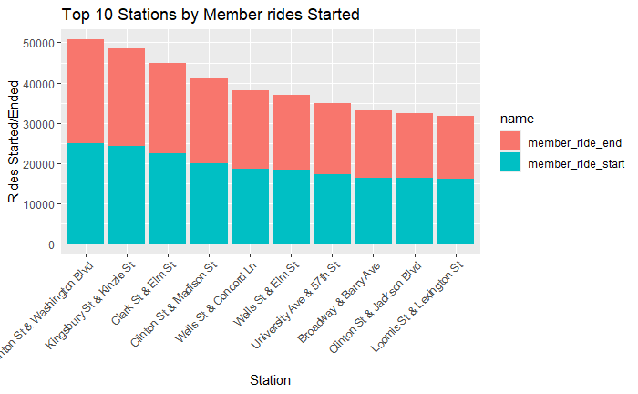

```r
start_stop <- left_join(

            (left_join(tripdata_cleanV1 %>%
                  filter(member_casual == 'member')%>%
                  group_by(station_name = start_station_name)%>%
                  summarise(member_ride_start  = (ride_id = n())),
                tripdata_cleanV1 %>%
                  filter(member_casual == 'member')%>%
                  group_by(station_name = end_station_name)%>%
                  summarise(member_ride_end = (ride_id = n())))),

            (left_join(tripdata_cleanV1 %>%
                    filter(member_casual == 'casual')%>%
                    group_by(station_name = start_station_name)%>%
                    summarise(casual_ride_start  = (ride_id = n())),
                  tripdata_cleanV1 %>%
                    filter(member_casual == 'casual')%>%
                    group_by(station_name = end_station_name)%>%
                    summarise(casual_ride_end = (ride_id = n())))))
top_member_start <- top_n(start_stop, 10, member_ride_start)%>%
                          select(station_name, member_ride_start, member_ride_end)%>%
                          pivot_longer(!station_name)

top_member_end <- top_n(start_stop, 10, member_ride_end)%>%
                          select(station_name, member_ride_start, member_ride_end)%>%
                          pivot_longer(!station_name)

top_casual_start <- top_n(start_stop, 10, casual_ride_start)%>%
                          select(station_name, casual_ride_start, casual_ride_end)%>%
                          pivot_longer(!station_name)

top_casual_end <- top_n(start_stop, 10, casual_ride_end)%>%
                          select(station_name, casual_ride_start, casual_ride_end)%>%
                          pivot_longer(!station_name)

ggplot(data = top_member_start)+
  geom_col(mapping = aes(y = value, x = reorder(station_name, -value), fill =  name, ))+
  labs(title = 'Top 10 Stations by Member rides Started')+
  theme(axis.text.x = element_text(angle = 45, hjust = 1 ))+
  scale_x_discrete (name = 'Station')+
  scale_y_continuous(name = 'Rides Started/Ended')
```

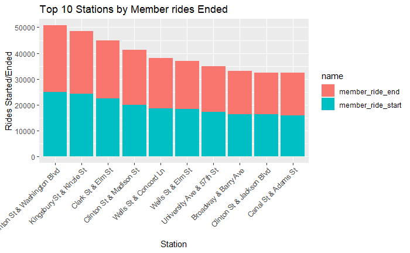

```r
ggplot(data = top_member_end)+
  geom_col(mapping = aes(y = value, x = reorder(station_name, -value), fill =  name, ))+
  labs(title = 'Top 10 Stations by Member rides Ended')+
  theme(axis.text.x = element_text(angle = 45, hjust = 1 ))+
  scale_x_discrete (name = 'Station')+
  scale_y_continuous(name = 'Rides Started/Ended')
```

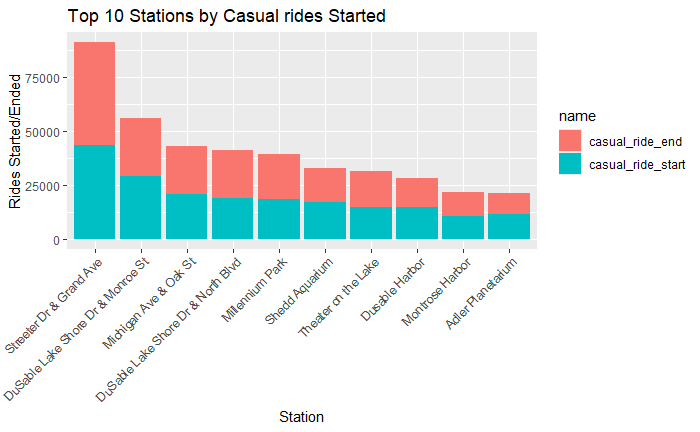

```r
ggplot(data = top_casual_start)+
  geom_col(mapping = aes(y = value, x = reorder(station_name, -value), fill =  name, ))+
  labs(title = 'Top 10 Stations by Casual rides Started')+
  theme(axis.text.x = element_text(angle = 45, hjust = 1 ))+
  scale_x_discrete (name = 'Station')+
  scale_y_continuous(name = 'Rides Started/Ended')
```

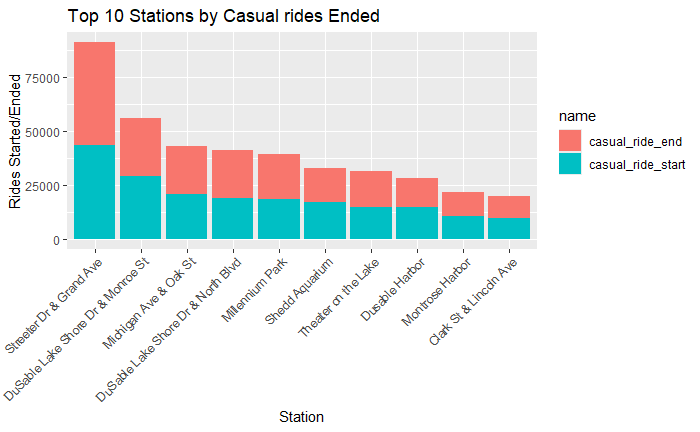

```r
ggplot(data = top_casual_end)+
  geom_col(mapping = aes(y = value, x = reorder(station_name, -value), fill =  name, ))+
  labs(title = 'Top 10 Stations by Casual rides Ended')+
  theme(axis.text.x = element_text(angle = 45, hjust = 1 ))+
  scale_x_discrete (name = 'Station')+
  scale_y_continuous(name = 'Rides Started/Ended')
```

With these charts we can see that casual users most often ride the bikes to and from popular leisure locations such as Streeter Dr & Grand Ave which is the location of Navy Pier in Chicago and DuSable Lake Shore Dr a road that follows the scenic waterfront of Lake Michigan. We also see that the most popular member start and end location is (Clinton St & Washington Blvd) at the Ogilvie Transportation Center which is a train station in downtown Chicago and the second most used station is not far away in the River North neighborhood. To confirm my suspicions I’ll look at what days of the week are most popular for each type of rider.

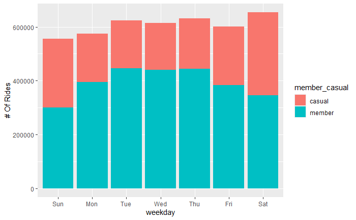

```r
rides_weekdays <- tripdata_cleanV1 %>%
                            mutate(weekday = wday(tripdata_cleanV1$started_at,label = TRUE))

ggplot(rides_weekdays)+
  stat_count(mapping = aes(weekday, fill = member_casual))+
  scale_y_continuous(name = '# Of Rides',labels = function(x) format(x, scientific = FALSE))
```

## Conclusion

with this final graph we can easily see that midweek rides are most common with member users. Combining this data we can now say with some certainty that member users are using the bikes for short rides in town, year round for day to day use during the middle of the week, most likely to commute to and from work .